# Genome Assembly

### SPAdes

SPAdes is another assembly program. Here by default there are several rounds of assembly trying different kmer lengths ‘-k’. Here there are also a few extra error correction modules. In general SPAdes requires more computation time and resources, but yields a better assembly.

[metaSPAdes paper](https://genome.cshlp.org/content/27/5/824)

```bash
metaspades.py -t 8 -k 21,33,55,77 -1 data/unmapped.R1.fq -2 data/unmapped.R2.fq -o spades_output
```

Look at contigs:

```r
contigs = readDNAStringSet('spades_output/contigs.fasta', format='fasta')
print(contigs)
```

```
## DNAStringSet object of length 82653:
##         width seq                                           names
##     [1] 29859 ATACCTTCCCAGGTAACAAAC...ATAGCTTCTTAGGAGAATGAC NODE_1_length_298...
##     [2]  6609 GACGCTGCCACGGCCACCTCC...CTGATGGCCGGCGCGATCGAC NODE_2_length_660...
##     [3]  6233 ACGCGGCCGCGCGTGGGGCGC...TTTTCTCTGGGACGAGGCCGG NODE_3_length_623...
##     [4]  5811 CATATCTTTACCAAGCAGGCG...AGAGATGCAGATTAACGAGAA NODE_4_length_581...
##     [5]  5577 GTCAGGTACAAAGACAGTCGT...GTCATGCCGGCGACGCGCTGC NODE_5_length_557...
##     ...   ... ...
## [82649]    78 GGGGAAGTCGGATCGTAGCCA...TGTCTTCCTAAGACCGCTTGG NODE_82649_length...
## [82650]    78 TGCGAAGTCGGAGGCCAAGCG...CTCACAGAACGACATGGCTAC NODE_82650_length...
## [82651]    78 TTGTCTTCCTAAGACCGCTTG...ATCCTACCATCGAAAGTTGAT NODE_82651_length...
## [82652]    78 TCCGACTTCCCGCTCGTCAGC...CGCACGCATGTCAGACTCCTA NODE_82652_length...
## [82653]    78 TTCTTAATCATTACCTCGTAT...TATTATTCCATGCAAGGAATA NODE_82653_length...
```

```r
maxcontig=max(contigs@ranges@width)
maxcontigSTR = contigs[which(contigs@ranges@width == maxcontig)]
as.character(maxcontigSTR)
```

```
##                                                                                                                                                                                                                                                                                                          …
## "ATACCTTCCCAGGTAACAAACCAACCAACTTTCGATCTCTTGTAGATCTGTTCTCTAAAC…"
```

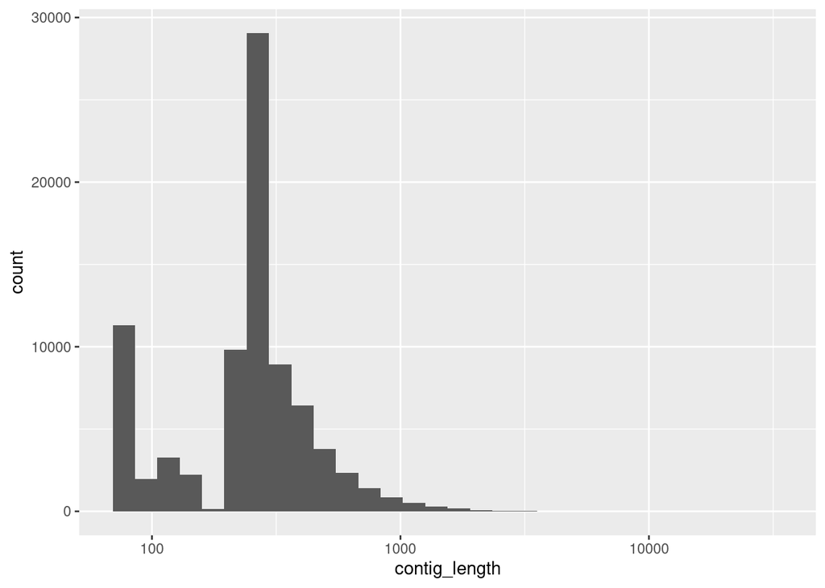

```r
widths = data.frame(contigs@ranges@width)
names(widths) = 'contig_length'
ggplot(widths) +
  geom_histogram(aes(x=contig_length)) +
  scale_x_log10()
```

### MEGAHIT

- Tests multiple kmer lengths
- Optimized for cleaning up metagenomes (mixtures)

```bash
#installation: run ONLY ONCE, but path specific
wget https://github.com/voutcn/megahit/releases/download/v1.2.9/MEGAHIT-1.2.9-Linux-x86_64-static.tar.gz
tar zvxf MEGAHIT-1.2.9-Linux-x86_64-static.tar.gz
mv MEGAHIT-1.2.9-Linux-x86_64-static MEGAHIT

#run
./MEGAHIT/bin/megahit -t 8 -1 data/unmapped.R1.fq -2 data/unmapped.R2.fq  -o dirMEGAHIT
```

Look at contigs:

- see note about fasta headings: https://github.com/voutcn/megahit/issues/54

```r
contigs = readDNAStringSet('dirMEGAHIT/final.contigs.fa', format='fasta')
print(contigs)
```

```
## DNAStringSet object of length 18646:
##         width seq                                           names
##     [1]   345 CGAGCACTTCTGCGGGTTGGA...GTATCTGAATCGTTCCCGGAG k141_9326 flag=1 ...
##     [2]   377 ACGGTGGTTGCCTCGACGTCG...GACGGCGCGCAGGACGTCGGC k141_13988 flag=1...
##     [3]   391 TCTTCTATCCAGTTCAGCTGA...TTAATCCATGATGGATGTGCA k141_2332 flag=1 ...
##     [4]   423 CCTTTTCTTCACCGGGAGCAA...TGCCATAAAGCAGATCAACAC k141_0 flag=1 mul...
##     [5]   420 CCTGTAATCAGCATCTATCAC...GAAGACAATAGGTCCCATCAA k141_4664 flag=1 ...
##     ...   ... ...
## [18642]   502 CCGCCGACCGCTTGAAGGACC...GAGACCGCTGCGGCAGCGGCC k141_6990 flag=1 ...
## [18643]   405 ACCCAGTCGGCGGCATGGTCG...TCGGCCTCGCGCTGGCCTTGC k141_6991 flag=1 ...
## [18644]   305 GGCCGCTGCCGACGTTGTAGG...CTCTTGAAGTGCTTCTCGTAC k141_6992 flag=1 ...
## [18645]   635 GACTACAAAGAGGCCGGAGAC...CGTGTGACTTGCTTGAAGTAC k141_6993 flag=1 ...
## [18646]   566 GCCCGGCGCAGGACTGGTTCG...GCTGTCCGCCCGCATCTCGAG k141_6994 flag=1 ...
```

```r
maxcontig=max(contigs@ranges@width)
maxcontigSTR = contigs[which(contigs@ranges@width == maxcontig)]
as.character(maxcontigSTR)
```

```
##                                                                                                                                                                                                                                                                                                          …
## "GGGGATAGCACTACTAAAATTAATTTTACACATTAGGGCTCTTCCATATAGGCAGCTCTC…"
```

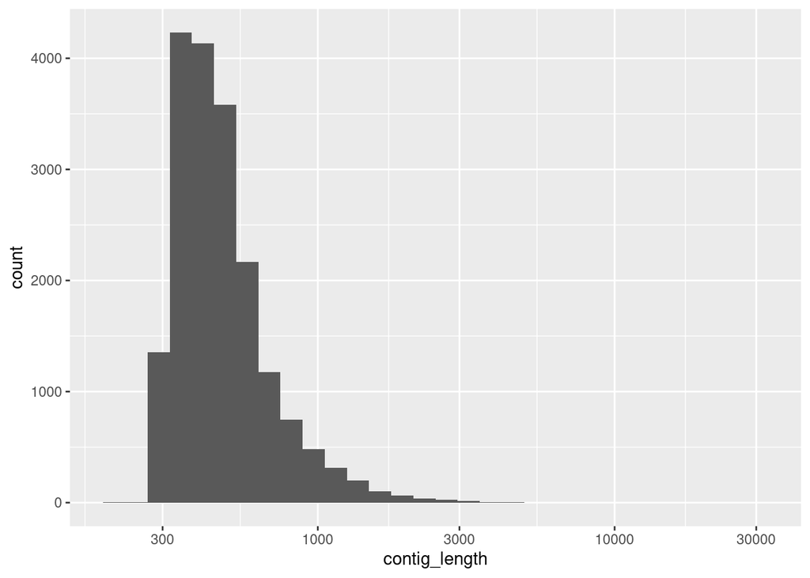

```r
widths = data.frame(contigs@ranges@width)
names(widths) = 'contig_length'
ggplot(widths) +
  geom_histogram(aes(x=contig_length)) +
  scale_x_log10()
```

[home](https://bio331.devbioinformatics.org)